# Figure 4h - number of interacting enhancers, histograms

This workbook is creating histograms for the number of interacting enhancers in Figure 4h of stable and downregulated genes. This uses the EM and Louvain clustering we have switched to during the paper revision.

Looking at the original Figure 4h I decided that it wasn’t the best way to represent the data. In particular, I didn’t like the jitter for the number of enhancers. Let’s see what the histograms look like.

Starting with cluster group active P - active E (active promoter, active enhancer). Having two groups of genes, the ones that change expression (ie in the TET TKO WT comparison) and those that don’t change expression.

Loading packages and options

```r
library(tidyverse)
options(scipen = 999)
source("cluster_analysis_functions.R")
```

Importing data

```r
read_tsv("../data/interaction_pairs_uncapped.txt") -> magic_table_uncapped
read_tsv("../data/Annotated Probe Report for DE TET Epi WT vs KO no MTC.txt") -> TET_WT_vs_KO_import
```

Finding the group of downregulated genes (TET DE without MTC)

```r
TET_WT_vs_KO_import %>%
  select(Probe, TET_WT_Epi_2, TET_KO_Epi_2) %>%
  distinct(Probe, .keep_all = TRUE) %>%
  filter(TET_KO_Epi_2 < TET_WT_Epi_2) %>%
  pull(Probe) -> TET_KO_down_genes
```

## EM clustering

Plotting the number of enhancer interactions for TET KO down and stable genes that are found in the magic table.

```r
magic_table_uncapped %>%
  filter(EM_cluster_group == "active P - active E") %>%
  select(interaction_ID, P_gene, RNA_TET_WT_EpiLC_D2, RNA_TET_KO_EpiLC_D2) %>%
  drop_na() %>%
  mutate(group = case_when(P_gene %in% TET_KO_down_genes ~ "TET_KO_down",
                           RNA_TET_WT_EpiLC_D2 - RNA_TET_KO_EpiLC_D2 > -0.25 & RNA_TET_WT_EpiLC_D2 - RNA_TET_KO_EpiLC_D2 < 0.25 ~ "stable_genes")) -> activeE_groups_EM

head(activeE_groups_EM)
```

| interaction_ID | P_gene | RNA_TET_WT_EpiLC_D2 | RNA_TET_KO_EpiLC_D2 | group |
| --- | --- | --- | --- | --- |
| 1_6204962_6208597...1_4969970_4971074 | Rb1cc1 | 1.890206 | 1.663403 | stable_genes |
| 1_9693269_9703555...1_9628157_9629017 | Mybl1 | 1.661296 | 1.972962 | NA |
| 1_9693269_9703555...1_9629018_9630659 | Mybl1 | 1.661296 | 1.972962 | NA |
| 1_10006483_10014224...1_9745988_9746386 | Ppp1r42 | -4.229234 | -3.850886 | NA |
| 1_17144886_17150063...1_17665782_17666519 | Gdap1 | -5.892649 | -6.194625 | NA |
| 1_24000570_24014397...1_23919085_23919426 | Gm26524 | -2.263864 | -1.936183 | NA |

How many do we get for downregulated and stable?

```r
activeE_groups_EM %>%
  group_by(group) %>%
  distinct(P_gene, .keep_all = TRUE) %>% # we need this here because we have several interactions per gene
  count() -> groups_counted_EM

groups_counted_EM
```

| group | n |
| --- | --- |
| TET_KO_down | 145 |
| stable_genes | 945 |
| NA | 3156 |

```r
groups_counted_EM %>%
  filter(group == "TET_KO_down") %>%
  pull(n) -> number_KO_genes
```

I found that there are 405 interactions that involved a total of 145 TET KO down genes in this data frame and I want to have the same number of stable genes.

```r
set.seed(6)

activeE_groups_EM %>%
  filter(group == "stable_genes") %>%
  distinct(P_gene) %>%
  slice_sample(n = number_KO_genes) %>%
  pull() -> stable_genes_selected_EM
```

Now going back to the original magic table filtering for the active P - active E cluster group (EM) selecting expression selecting stable and knocked down genes

```r
magic_table_uncapped %>%
  filter(EM_cluster_group == "active P - active E") %>%
  select(interaction_ID, P_gene, RNA_TET_WT_EpiLC_D2, RNA_TET_KO_EpiLC_D2) %>%
  mutate(group = case_when(P_gene %in% TET_KO_down_genes ~ "TET_KO_down",
                           P_gene %in% stable_genes_selected_EM ~ "stable")) %>%
  filter(!is.na(group)) -> expression_data_EM

head(expression_data_EM)
```

| interaction_ID | P_gene | RNA_TET_WT_EpiLC_D2 | RNA_TET_KO_EpiLC_D2 | group |
| --- | --- | --- | --- | --- |
| 1_72208526_72221100...1_71642345_71643458 | Mreg | 5.040498 | 3.90156770 | TET_KO_down |
| 1_82836128_82848005...1_82855721_82856041 | Agfg1 | 3.713675 | 3.80481839 | stable |
| 1_85894237_85899701...1_86335657_86335990 | Itm2c | 4.117761 | 3.92940068 | stable |
| 1_136959986_136960563...1_136533570_136535518 | Nr5a2 | 1.701339 | -0.02707148 | TET_KO_down |
| 1_152951925_152956721...1_153007990_153010461 | Nmnat2 | 2.027131 | 0.51419050 | TET_KO_down |
| 1_152951925_152956721...1_153095424_153096329 | Nmnat2 | 2.027131 | 0.51419050 | TET_KO_down |

Finding the number of enhancers for each gene

```r
expression_data_EM %>%
  group_by(P_gene) %>%
  add_count() %>%
  select(P_gene, group, n) %>%
  distinct() -> enhancer_counts_EM

head(enhancer_counts_EM)
```

| P_gene | group | n |
| --- | --- | --- |
| Mreg | TET_KO_down | 1 |
| Agfg1 | stable | 1 |
| Itm2c | stable | 1 |
| Nr5a2 | TET_KO_down | 1 |
| Nmnat2 | TET_KO_down | 4 |
| Atp1a2 | TET_KO_down | 1 |

Plotting histograms

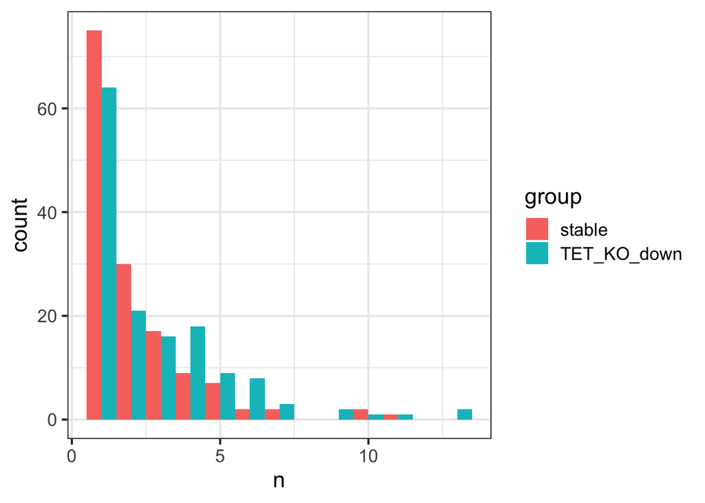

```r
bin_number_EM <- max(enhancer_counts_EM$n)

enhancer_counts_EM %>%
  ggplot(aes(n, fill = group)) +
  geom_histogram(bins = bin_number_EM, position = "dodge")
```

Hm, I don’t really like this. How about a line graph where the data points can be on at the same location on the x axis?

### Enhancer count line plot EM

```r
enhancer_counts_EM %>%
  group_by(group, n) %>%
  count() %>%
  mutate(group = if_else(group == "stable", "Stable", "Downregulated")) %>%
  mutate(group = factor(group, levels = c("Stable", "Downregulated"))) -> enhancer_counts_sum_EM
```

```
## Storing counts in `nn`, as `n` already present in input
## ℹ Use `name = "new_name"` to pick a new name.
```

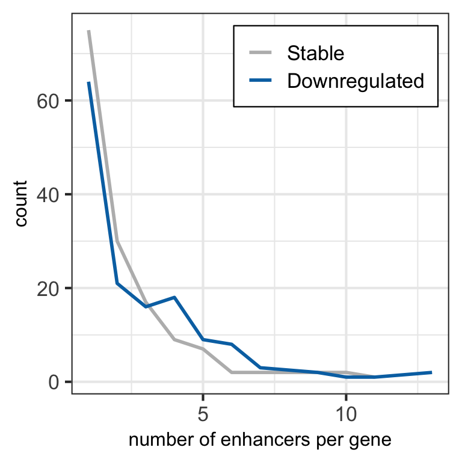

```r
enhancer_counts_sum_EM %>%
  ggplot(aes(n, nn, colour = group)) +
  geom_line(size = 1) +
  ylab("count") +
  xlab("number of enhancers per gene") +
  scale_colour_manual(values = c("#bababa", down_colour)) +
  theme(legend.position = "inside", legend.position.inside = c(0.7, 0.86), legend.title = element_blank(), axis.title = element_text(size = 12),
        legend.background = element_rect(colour = "black", size = 0.4)) -> enhancer_count_line_plot_EM
enhancer_count_line_plot_EM
```

Exporting

```r
ggsave("../output/plots/Figure4h_number_enhancer_line_EM.png", enhancer_count_line_plot_EM, width = 4, height = 4, units = "in")
ggsave("../output/plots/Figure4h_number_enhancer_line_EM.svg", enhancer_count_line_plot_EM, width = 4, height = 4, units = "in")
```

## Louvain clustering

Plotting the number of enhancers for TET KO down and stable genes that are found in the magic table.

```r
magic_table_uncapped %>%
  filter(Louvain_cluster_group == "active P - active E") %>%
  select(interaction_ID, P_gene, RNA_TET_WT_EpiLC_D2, RNA_TET_KO_EpiLC_D2) %>%
  drop_na() %>%
  mutate(group = case_when(P_gene %in% TET_KO_down_genes ~ "TET_KO_down",
                           RNA_TET_WT_EpiLC_D2 - RNA_TET_KO_EpiLC_D2 > -0.25 & RNA_TET_WT_EpiLC_D2 - RNA_TET_KO_EpiLC_D2 < 0.25 ~ "stable_genes")) -> activeE_groups_Louvain

head(activeE_groups_Louvain)
```

| interaction_ID | P_gene | RNA_TET_WT_EpiLC_D2 | RNA_TET_KO_EpiLC_D2 | group |
| --- | --- | --- | --- | --- |
| 1_9693269_9703555...1_9628157_9629017 | Mybl1 | 1.661296 | 1.9729625 | NA |
| 1_9693269_9703555...1_9629018_9630659 | Mybl1 | 1.661296 | 1.9729625 | NA |
| 1_9693269_9703555...1_9630660_9633731 | Mybl1 | 1.661296 | 1.9729625 | NA |
| 1_10006483_10014224...1_9745988_9746386 | Ppp1r42 | -4.229234 | -3.8508856 | NA |
| 1_10031137_10039429...1_9742294_9743249 | Cspp1 | 0.705873 | 0.9993253 | NA |
| 1_16616288_16619712...1_17058648_17059297 | Gm38342 | -5.197630 | -4.8699498 | NA |

How many do we get for downregulated and stable?

```r
activeE_groups_Louvain %>%
  group_by(group) %>%
  distinct(P_gene, .keep_all = TRUE) %>% # we need this here because we have several interactions per gene
  count() -> groups_counted_Louvain

groups_counted_Louvain
```

| group | n |
| --- | --- |
| TET_KO_down | 170 |
| stable_genes | 1115 |
| NA | 2915 |

```r
groups_counted_Louvain %>%
  filter(group == "TET_KO_down") %>%
  pull(n) -> number_KO_genes
```

I found that there are 170 TET KO down genes in this data frame and I want to have the same number of stable genes.

```r
set.seed(6)

activeE_groups_Louvain %>%
  filter(group == "stable_genes") %>%
  distinct(P_gene) %>%
  slice_sample(n = number_KO_genes) %>%
  pull() -> stable_genes_selected_Louvain
```

Now going back to the original magic table filtering for the active P - active E cluster group (Louvain) selecting expression selecting stable and knocked down genes

```r
magic_table_uncapped %>%
  filter(Louvain_cluster_group == "active P - active E") %>%
  select(interaction_ID, P_gene, RNA_TET_WT_EpiLC_D2, RNA_TET_KO_EpiLC_D2) %>%
  mutate(group = case_when(P_gene %in% TET_KO_down_genes ~ "TET_KO_down",
                           P_gene %in% stable_genes_selected_Louvain ~ "stable")) %>%
  filter(!is.na(group)) -> expression_data_Louvain

head(expression_data_Louvain)
```

| interaction_ID | P_gene | RNA_TET_WT_EpiLC_D2 | RNA_TET_KO_EpiLC_D2 | group |
| --- | --- | --- | --- | --- |
| 1_60340837_60344684...1_60849176_60850867 | Cyp20a1 | 4.165368 | 3.997693 | stable |
| 1_60340837_60344684...1_60857730_60859937 | Cyp20a1 | 4.165368 | 3.997693 | stable |
| 1_72208526_72221100...1_71569800_71573094 | Mreg | 5.040498 | 3.901568 | TET_KO_down |
| 1_72208526_72221100...1_71642345_71643458 | Mreg | 5.040498 | 3.901568 | TET_KO_down |
| 1_72208526_72221100...1_71656277_71659935 | Mreg | 5.040498 | 3.901568 | TET_KO_down |
| 1_75168548_75175792...1_74821270_74822466 | Zfand2b | 3.724056 | 3.915047 | stable |

Finding the number of enhancers for each gene

```r
expression_data_Louvain %>%
  group_by(P_gene) %>%
  add_count() %>%
  select(P_gene, group, n) %>%
  distinct() -> enhancer_counts_Louvain

head(enhancer_counts_Louvain)
```

| P_gene | group | n |
| --- | --- | --- |
| Cyp20a1 | stable | 2 |
| Mreg | TET_KO_down | 3 |
| Zfand2b | stable | 4 |
| Tuba4a | TET_KO_down | 1 |
| Nmnat2 | TET_KO_down | 1 |
| Atp1a2 | TET_KO_down | 2 |

### Enhancer count line plot Louvain

```r
enhancer_counts_Louvain %>%
  group_by(group, n) %>%
  count() %>%
  mutate(group = if_else(group == "stable", "Stable", "Downregulated")) %>%
  mutate(group = factor(group, levels = c("Stable", "Downregulated"))) -> enhancer_counts_sum_Louvain
```

```
## Storing counts in `nn`, as `n` already present in input
## ℹ Use `name = "new_name"` to pick a new name.
```

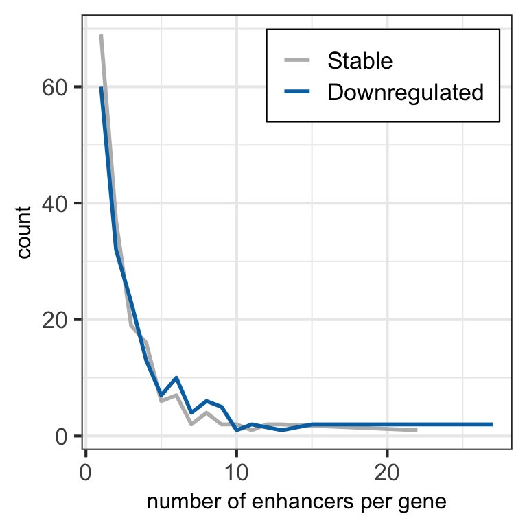

```r
enhancer_counts_sum_Louvain %>%
  ggplot(aes(n, nn, colour = group)) +
  geom_line(size = 1) +
  ylab("count") +
  xlab("number of enhancers per gene") +
  scale_colour_manual(values = c("#bababa", down_colour)) +
  theme(legend.position = "inside", legend.position.inside = c(0.7, 0.86), legend.title = element_blank(), axis.title = element_text(size = 12),
        legend.background = element_rect(colour = "black", size = 0.4)) -> enhancer_count_line_plot_Louvain

enhancer_count_line_plot_Louvain
```

Exporting

```r
ggsave("../output/plots/Figure4h_number_enhancer_line_Louvain.png", enhancer_count_line_plot_Louvain, width = 4, height = 4, units = "in")
ggsave("../output/plots/Figure4h_number_enhancer_line_Louvain.svg", enhancer_count_line_plot_Louvain, width = 4, height = 4, units = "in")
```